# ANOVA

Jesse

2019年12月3日

**ANOVA**, analysis of variance, based on compare *between-group* variances & *within-group* variances.  
And we reject H<sub>0</sub> if between-variance significantly > within-variance.

We use `aov` function to conduct ANOVA.  
Meanwhile, we have to do two more things to conduct our ANOVA.

1. We have to change variables into **categorical variable** before conduct ANOVA.
2. We have to furthur use `summary` to see the result.

Here we use dataset **babies**.(https://www.openintro.org/stat/data.php?data=babies)  
In `babies`, researchers investigate a range of topics about pregnancies and infants.  
We wanna see that whether average birthweight varies with mother’s age.

- bwt: birthweight
- gestation: length of gestation
- age: mother’s age in years

## Load dataset.

After loading dataset, we try filtering out the missing values.

```r
babies <- read.csv("C:/Users/asus/Desktop/TA/TA session/week12/babies.csv")
babies <- babies[complete.cases(babies),]
```

## Convert age into categorical variables.

We did this by convert *age* into **factor**.

```r
babies$age <- factor(babies$age)
```

And we use `levels` to see how many ages do we have.

```r
levels(babies$age)
```

```
##  [1] "15" "17" "18" "19" "20" "21" "22" "23" "24" "25" "26" "27" "28" "29"
## [15] "30" "31" "32" "33" "34" "35" "36" "37" "38" "39" "40" "41" "42" "43"
## [29] "44" "45"
```

## Plots

As there are too many different ages in the dataset,  
we directly use some plots to see the difference.

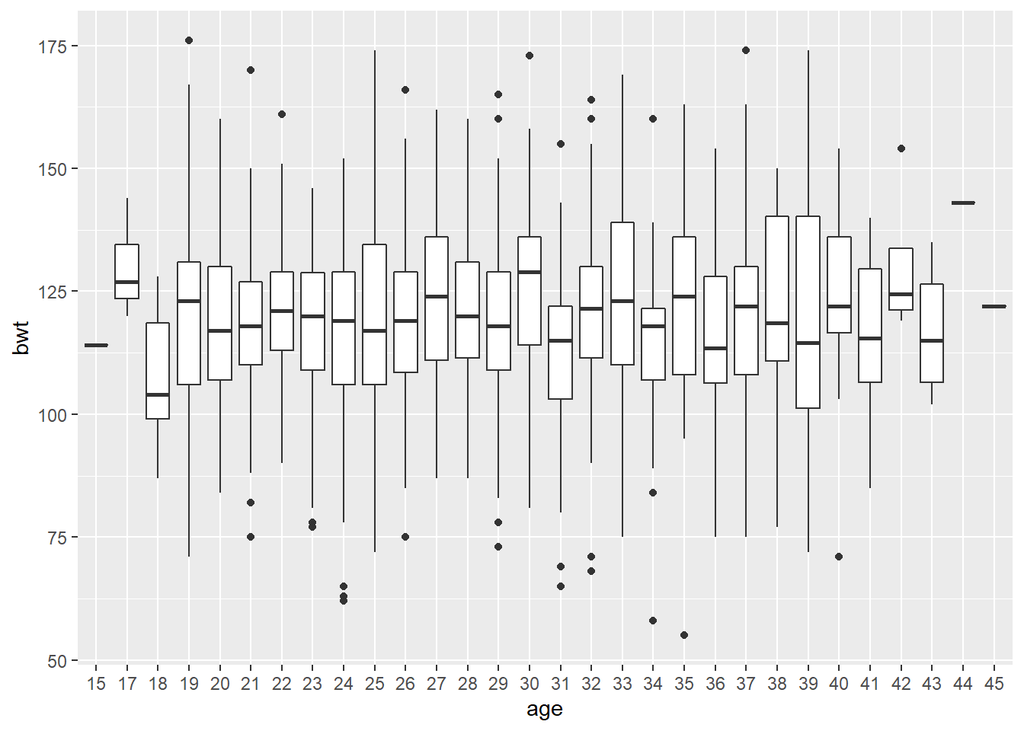

```r
## Boxplot
ggplot(data=babies) +
  geom_boxplot(mapping = aes(x=age, y=bwt))
```

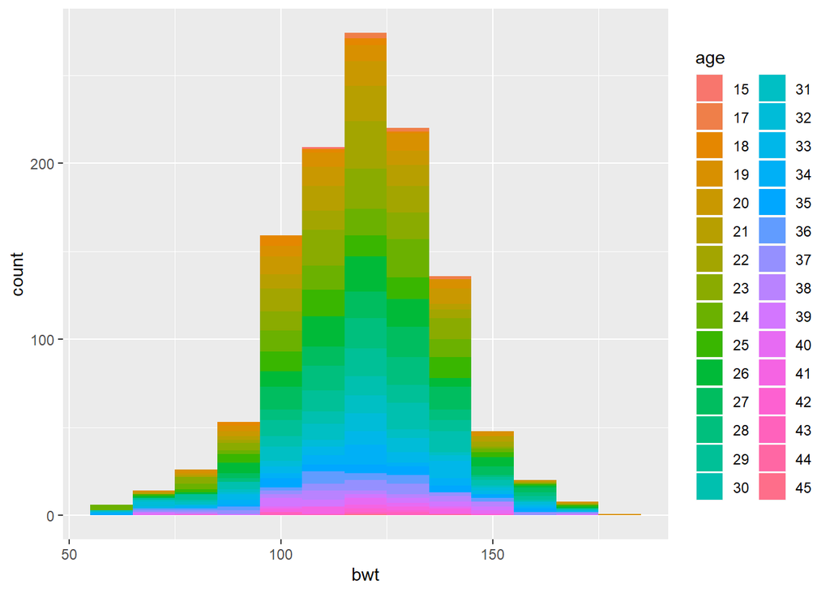

```r
##Barplot
ggplot(data = babies) +
  geom_histogram(mapping = aes(x=bwt, fill=age), binwidth = 10)
```

## ANOVA test

Finally, we conduct anova test to see the result.

```r
aov_result <- aov(bwt~age, data = babies)
summary(aov_result)
```

```
##               Df Sum Sq Mean Sq F value Pr(>F)
## age           29  12869   443.7   1.332  0.113
## Residuals   1144 381189   333.2
```

### Question

1. Check whether average length of gestation varies with mother’s age.
2. Use dataset **mlb_player_18** (https://www.openintro.org/stat/data.php?data=mlb_players_18). Check whether average *AVG* varies with *position*. Filter out data with missing values or where it’s *AB* < 10.